# Divvy Rideshare 2024(January-June) data Analysis

Miss. Chaitali Dikholkar

2024-07-04

### Load and install tidyverse package

```
##
##  C:\Users\shiv\AppData\Local\Temp\RtmpSi6Xt6\downloaded_packages
```

### Use the conflicted package to manage conflicts

```r
library(conflicted)
```

###Set dplyr::filter and dplyr::lag as the default choices

```r
conflict_prefer("filter", "dplyr")
```

```
## [conflicted] Will prefer dplyr::filter over any other package.
```

```r
conflict_prefer("lag", "dplyr")
```

```
## [conflicted] Will prefer dplyr::lag over any other package.
```

=====================  
#STEP 1: COLLECT DATA  
=====================  
###load library readr

```r
library(readr)
```

```r
all_trips <- read_csv("F:\\my_Data\\Case_study_1_data\\My_final_analysis\\2024_divvy_bikeshare_analysis\\all_trips1-6month_data.csv")
```

```
## ──────────────────────────────────────────────────────── Delimiter: "," chr
## (7): ride_id, rideable_type, start_station_name, start_station_id, end_... dbl
## (5): ...1, start_lat, start_lng, end_lat, end_lng dttm (2): started_at,
## ended_at
```

```r
View(all_trips)
```

====================================================  
#STEP 2: WRANGLE DATA AND COMBINE INTO A SINGLE FILE  
====================================================  
###Compare column names each of the files  
While the names don’t have to be in the same order, they DO need to match perfectly before  
we can use a command to join them into one file

```r
colnames(all_trips)
```

```
##  [1] "...1"               "ride_id"            "rideable_type"
##  [4] "started_at"         "ended_at"           "start_station_name"
##  [7] "start_station_id"   "end_station_name"   "end_station_id"
## [10] "start_lat"          "start_lng"          "end_lat"
## [13] "end_lng"            "member_casual"
```

###Inspect the dataframes and look for incongruencies

```r
str(all_trips)
```

```
## spc_tbl_ [2,409,883 × 14] (S3: spec_tbl_df/tbl_df/tbl/data.frame)
##  $ ...1              : num [1:2409883] 1 2 3 4 5 6 7 8 9 10 ...
##  $ ride_id           : chr [1:2409883] "A005A42F49BDF885" "25AFF61A2083ADDB" "5FE9C07CAE30A698" "BFE3CB86951CECA6" ...
##  $ rideable_type     : chr [1:2409883] "electric_bike" "electric_bike" "electric_bike" "classic_bike" ...
##  $ started_at        : POSIXct[1:2409883], format: "2024-06-01 00:00:00" "2024-06-01 00:00:00" ...
##  $ ended_at          : POSIXct[1:2409883], format: "2024-06-01 00:04:00" "2024-06-01 00:13:00" ...
##  $ start_station_name: chr [1:2409883] NA "Broadway & Granville Ave" "Wilton Ave & Belmont Ave" "Southport Ave & Waveland Ave" ...
##  $ start_station_id  : chr [1:2409883] NA "15571" "TA1307000134" "13235" ...
##  $ end_station_name  : chr [1:2409883] NA "Sheridan Rd & Loyola Ave" NA "Wilton Ave & Belmont Ave" ...
##  $ end_station_id    : chr [1:2409883] NA "RP-009" NA "TA1307000134" ...
##  $ start_lat         : num [1:2409883] 41.9 42 41.9 41.9 41.9 ...
##  $ start_lng         : num [1:2409883] -87.7 -87.7 -87.7 -87.7 -87.6 ...
##  $ end_lat           : num [1:2409883] 41.9 42 41.9 41.9 41.9 ...
##  $ end_lng           : num [1:2409883] -87.7 -87.7 -87.6 -87.7 -87.7 ...
##  $ member_casual     : chr [1:2409883] "casual" "casual" "member" "casual" ...
##  - attr(*, "spec")=
##   .. cols(
##   ..   ...1 = col_double(),
##   ..   ride_id = col_character(),
##   ..   rideable_type = col_character(),
##   ..   started_at = col_datetime(format = ""),
##   ..   ended_at = col_datetime(format = ""),
##   ..   start_station_name = col_character(),
##   ..   start_station_id = col_character(),
##   ..   end_station_name = col_character(),
##   ..   end_station_id = col_character(),
##   ..   start_lat = col_double(),
##   ..   start_lng = col_double(),
##   ..   end_lat = col_double(),
##   ..   end_lng = col_double(),
##   ..   member_casual = col_character()
##   .. )
##  - attr(*, "problems")=<externalptr>
```

```r
all_trips <- all_trips %>%
  select(-c(start_lat, start_lng, end_lat, end_lng))
colnames(all_trips)
```

```
##  [1] "...1"               "ride_id"            "rideable_type"
##  [4] "started_at"         "ended_at"           "start_station_name"
##  [7] "start_station_id"   "end_station_name"   "end_station_id"
## [10] "member_casual"
```

======================================================  
#STEP 3: CLEAN UP AND ADD DATA TO PREPARE FOR ANALYSIS  
======================================================  
###Inspect the new table that has been created

```r
colnames(all_trips) #List of column names
```

```
##  [1] "...1"               "ride_id"            "rideable_type"
##  [4] "started_at"         "ended_at"           "start_station_name"
##  [7] "start_station_id"   "end_station_name"   "end_station_id"
## [10] "member_casual"
```

```r
nrow(all_trips) #How many rows are in data frame?
```

```
## [1] 2409883
```

```r
dim(all_trips) #Dimensions of the data frame?
```

```
## [1] 2409883      10
```

```r
head(all_trips) #See the first 6 rows of data frame. Also tail(all_trips)
```

```
## # A tibble: 6 × 10
##    ...1 ride_id          rideable_type started_at          ended_at
##   <dbl> <chr>            <chr>         <dttm>              <dttm>
## 1     1 A005A42F49BDF885 electric_bike 2024-06-01 00:00:00 2024-06-01 00:04:00
## 2     2 25AFF61A2083ADDB electric_bike 2024-06-01 00:00:00 2024-06-01 00:13:00
## 3     3 5FE9C07CAE30A698 electric_bike 2024-06-01 00:00:00 2024-06-01 00:10:00
## 4     4 BFE3CB86951CECA6 classic_bike  2024-06-01 00:00:00 2024-06-01 00:08:00
## 5     5 E23C19E42E95E1AF classic_bike  2024-06-01 00:00:00 2024-06-01 00:07:00
## 6     6 7D0AFA3D844F8881 electric_bike 2024-06-01 00:00:00 2024-06-01 00:12:00
## # ℹ 5 more variables: start_station_name <chr>, start_station_id <chr>,
## #   end_station_name <chr>, end_station_id <chr>, member_casual <chr>
```

```r
str(all_trips) #See list of columns and data types (numeric, character, etc)
```

```
## tibble [2,409,883 × 10] (S3: tbl_df/tbl/data.frame)
##  $ ...1              : num [1:2409883] 1 2 3 4 5 6 7 8 9 10 ...
##  $ ride_id           : chr [1:2409883] "A005A42F49BDF885" "25AFF61A2083ADDB" "5FE9C07CAE30A698" "BFE3CB86951CECA6" ...
##  $ rideable_type     : chr [1:2409883] "electric_bike" "electric_bike" "electric_bike" "classic_bike" ...
##  $ started_at        : POSIXct[1:2409883], format: "2024-06-01 00:00:00" "2024-06-01 00:00:00" ...
##  $ ended_at          : POSIXct[1:2409883], format: "2024-06-01 00:04:00" "2024-06-01 00:13:00" ...
##  $ start_station_name: chr [1:2409883] NA "Broadway & Granville Ave" "Wilton Ave & Belmont Ave" "Southport Ave & Waveland Ave" ...
##  $ start_station_id  : chr [1:2409883] NA "15571" "TA1307000134" "13235" ...
##  $ end_station_name  : chr [1:2409883] NA "Sheridan Rd & Loyola Ave" NA "Wilton Ave & Belmont Ave" ...
##  $ end_station_id    : chr [1:2409883] NA "RP-009" NA "TA1307000134" ...
##  $ member_casual     : chr [1:2409883] "casual" "casual" "member" "casual" ...
```

```r
summary(all_trips) #Statistical summary of data. Mainly for numerics
```

```
##       ...1           ride_id          rideable_type
##  Min.   :      1   Length:2409883     Length:2409883
##  1st Qu.: 602472   Class :character   Class :character
##  Median :1204942   Mode  :character   Mode  :character
##  Mean   :1204942
##  3rd Qu.:1807413
##  Max.   :2409883
##    started_at                        ended_at
##  Min.   :2024-01-01 00:00:00.00   Min.   :2024-01-01 00:04:00.00
##  1st Qu.:2024-03-25 07:32:00.00   1st Qu.:2024-03-25 07:43:00.00
##  Median :2024-05-07 17:16:00.00   Median :2024-05-07 17:31:00.00
##  Mean   :2024-04-27 13:48:13.75   Mean   :2024-04-27 14:05:59.33
##  3rd Qu.:2024-06-06 15:50:00.00   3rd Qu.:2024-06-06 16:08:00.00
##  Max.   :2024-06-30 23:59:00.00   Max.   :2024-07-02 00:39:00.00
##  start_station_name start_station_id   end_station_name   end_station_id
##  Length:2409883     Length:2409883     Length:2409883     Length:2409883
##  Class :character   Class :character   Class :character   Class :character
##  Mode  :character   Mode  :character   Mode  :character   Mode  :character
##
##
##
##  member_casual
##  Length:2409883
##  Class :character
##  Mode  :character
##
##
##
```

## #There are a few problems we will need to fix:

1. The data can only be aggregated at the ride-level, which is too granular. We will want to  
   add some additional columns of data – such as day, month, year – that provide additional  
   opportunities to aggregate the data.
2. We will want to add a calculated field for length of ride since the 2020Q1 data did not have  
   the “tripduration” column. We will add “ride_length” to the entire dataframe for consistency.
3. There are some rides where tripduration shows up as negative, including several hundred  
   rides where Divvy took bikes out of circulation for Quality Control reasons. We will want to  
   delete these rides.
4. During data cleaning process in excel for 2023Q1 data found column rideable_type with 3 values  
   “docked_bike”, “electric_bike”, “classic_bike”, but data after 8/2023 found only 2 values “electric_ bike”, “classic_bike”.  
   —————————————————————————————————-  
   Add columns that list the date, month, day, and year of each ride  
   This will allow us to aggregate ride data for each month, day, or year … before completing  
   these operations we could only aggregate at the ride level  
   ———————————————————————————–  
   < https://www.statmethods.net/input/dates.html> more on date formats in R found at that link  
   ———————————————————————————–

```r
all_trips$date <- as.Date(all_trips$started_at) #The default format is yyyy-mm-dd
all_trips$month <- format(as.Date(all_trips$date), "%m")
all_trips$day <- format(as.Date(all_trips$date), "%d")
all_trips$year <- format(as.Date(all_trips$date), "%Y")
all_trips$day_of_week <- format(as.Date(all_trips$date), "%A")

str(all_trips)
```

```
## tibble [2,409,883 × 15] (S3: tbl_df/tbl/data.frame)
##  $ ...1              : num [1:2409883] 1 2 3 4 5 6 7 8 9 10 ...
##  $ ride_id           : chr [1:2409883] "A005A42F49BDF885" "25AFF61A2083ADDB" "5FE9C07CAE30A698" "BFE3CB86951CECA6" ...
##  $ rideable_type     : chr [1:2409883] "electric_bike" "electric_bike" "electric_bike" "classic_bike" ...
##  $ started_at        : POSIXct[1:2409883], format: "2024-06-01 00:00:00" "2024-06-01 00:00:00" ...
##  $ ended_at          : POSIXct[1:2409883], format: "2024-06-01 00:04:00" "2024-06-01 00:13:00" ...
##  $ start_station_name: chr [1:2409883] NA "Broadway & Granville Ave" "Wilton Ave & Belmont Ave" "Southport Ave & Waveland Ave" ...
##  $ start_station_id  : chr [1:2409883] NA "15571" "TA1307000134" "13235" ...
##  $ end_station_name  : chr [1:2409883] NA "Sheridan Rd & Loyola Ave" NA "Wilton Ave & Belmont Ave" ...
##  $ end_station_id    : chr [1:2409883] NA "RP-009" NA "TA1307000134" ...
##  $ member_casual     : chr [1:2409883] "casual" "casual" "member" "casual" ...
##  $ date              : Date[1:2409883], format: "2024-06-01" "2024-06-01" ...
##  $ month             : chr [1:2409883] "06" "06" "06" "06" ...
##  $ day               : chr [1:2409883] "01" "01" "01" "01" ...
##  $ year              : chr [1:2409883] "2024" "2024" "2024" "2024" ...
##  $ day_of_week       : chr [1:2409883] "Saturday" "Saturday" "Saturday" "Saturday" ...
```

###Add a “ride_length” calculation to all_trips (in seconds)

[output not shown]

## https://www.datasciencemadesimple.com/delete-or-drop-rows-in-r-with-conditions-2/

###Data removed

```r
all_trips_v2 <- all_trips[!(all_trips$start_station_name == "HQ QR" | all_trips$ride_length < 0
                            | all_trips$ride_length == 0),]

library(tidyr)
all_trips_v3 <- all_trips_v2 %>% drop_na()
View(all_trips_v3)
```

======================================  
#STEP 4: CONDUCT DESCRIPTIVE ANALYSIS  
=====================================

###Descriptive analysis on ride_length (all figures in seconds)  
straight average (total ride length / rides)  
midpoint number in the ascending array of ride lengths  
longest ride  
shortest ride

```r
mean(all_trips_v3$ride_length)
```

```
## [1] 1035.295
```

```r
median(all_trips_v3$ride_length)
```

```
## [1] 600
```

```r
max(all_trips_v3$ride_length)
```

```
## [1] 89880
```

```r
min(all_trips_v3$ride_length)
```

```
## [1] 60
```

You can condense the four lines above to one line using summary() on the specific attribute

```r
summary(all_trips_v3$ride_length)
```

```
##    Min. 1st Qu.  Median    Mean 3rd Qu.    Max.
##      60     360     600    1035    1140   89880
```

###Compare members and casual users

```r
aggregate(all_trips_v3$ride_length ~ all_trips_v3$member_casual, FUN = mean)
```

```
##   all_trips_v3$member_casual all_trips_v3$ride_length
## 1                     casual                 1535.901
## 2                     member                  773.867
```

```r
aggregate(all_trips_v3$ride_length ~ all_trips_v3$member_casual, FUN = median)
```

```
##   all_trips_v3$member_casual all_trips_v3$ride_length
## 1                     casual                      840
## 2                     member                      540
```

```r
aggregate(all_trips_v3$ride_length ~ all_trips_v3$member_casual, FUN = max)
```

```
##   all_trips_v3$member_casual all_trips_v3$ride_length
## 1                     casual                    89820
## 2                     member                    89880
```

```r
aggregate(all_trips_v3$ride_length ~ all_trips_v3$member_casual, FUN = min)
```

```
##   all_trips_v3$member_casual all_trips_v3$ride_length
## 1                     casual                       60
## 2                     member                       60
```

###See the average ride time by each day for members vs casual users

```r
aggregate(all_trips_v3$ride_length ~ all_trips_v3$member_casual + all_trips_v3$day_of_week,
          FUN = mean)
```

```
##    all_trips_v3$member_casual all_trips_v3$day_of_week all_trips_v3$ride_length
## 1                      casual                   Friday                1445.5241
## 2                      member                   Friday                 735.7986
## 3                      casual                   Monday                1508.5108
## 4                      member                   Monday                 736.9595
## 5                      casual                 Saturday                1739.6309
## 6                      member                 Saturday                 877.2224
## 7                      casual                   Sunday                1773.3291
## 8                      member                   Sunday                 885.5151
## 9                      casual                 Thursday                1295.4949
## 10                     member                 Thursday                 723.6378
## 11                     casual                  Tuesday                1310.6984
## 12                     member                  Tuesday                 745.1256
## 13                     casual                Wednesday                1389.6190
## 14                     member                Wednesday                 764.4121
```

###Notice that the days of the week are out of order. Let’s fix that.

```r
all_trips_v3$day_of_week <- ordered(all_trips_v3$day_of_week, levels=c("Sunday", "Monday",
                                                                       "Tuesday", "Wednesday", "Thursday", "Friday", "Saturday"))
```

###Now, let’s run the average ride time by each day for members vs casual users

```r
aggregate(all_trips_v3$ride_length ~ all_trips_v3$member_casual + all_trips_v3$day_of_week,
          FUN = mean)
```

```
##    all_trips_v3$member_casual all_trips_v3$day_of_week all_trips_v3$ride_length
## 1                      casual                   Sunday                1773.3291
## 2                      member                   Sunday                 885.5151
## 3                      casual                   Monday                1508.5108
## 4                      member                   Monday                 736.9595
## 5                      casual                  Tuesday                1310.6984
## 6                      member                  Tuesday                 745.1256
## 7                      casual                Wednesday                1389.6190
## 8                      member                Wednesday                 764.4121
## 9                      casual                 Thursday                1295.4949
## 10                     member                 Thursday                 723.6378
## 11                     casual                   Friday                1445.5241
## 12                     member                   Friday                 735.7986
## 13                     casual                 Saturday                1739.6309
## 14                     member                 Saturday                 877.2224
```

###Compare electric_bikes and classic_bikes users by agreegating data.

```r
aggregate(all_trips_v3$ride_length ~ all_trips_v3$rideable_type, FUN = mean)
```

```
##   all_trips_v3$rideable_type all_trips_v3$ride_length
## 1               classic_bike                1159.6589
## 2              electric_bike                 765.3015
```

```r
aggregate(all_trips_v3$ride_length ~ all_trips_v3$rideable_type, FUN = median)
```

```
##   all_trips_v3$rideable_type all_trips_v3$ride_length
## 1               classic_bike                      660
## 2              electric_bike                      540
```

```r
aggregate(all_trips_v3$ride_length ~ all_trips_v3$rideable_type, FUN = max)
```

```
##   all_trips_v3$rideable_type all_trips_v3$ride_length
## 1               classic_bike                    89880
## 2              electric_bike                    28800
```

```r
aggregate(all_trips_v3$ride_length ~ all_trips_v3$rideable_type, FUN = min)
```

```
##   all_trips_v3$rideable_type all_trips_v3$ride_length
## 1               classic_bike                       60
## 2              electric_bike                       60
```

```r
aggregate(all_trips_v3$ride_length ~ all_trips_v3$rideable_type + all_trips_v3$day_of_week,
          FUN = mean)
```

```
##    all_trips_v3$rideable_type all_trips_v3$day_of_week all_trips_v3$ride_length
## 1                classic_bike                   Sunday                1441.8480
## 2               electric_bike                   Sunday                 940.1287
## 3                classic_bike                   Monday                1084.9689
## 4               electric_bike                   Monday                 715.7554
## 5                classic_bike                  Tuesday                 996.4752
## 6               electric_bike                  Tuesday                 685.8533
## 7                classic_bike                Wednesday                1056.1042
## 8               electric_bike                Wednesday                 702.2559
## 9                classic_bike                 Thursday                 977.1865
## 10              electric_bike                 Thursday                 684.2306
## 11               classic_bike                   Friday                1094.8230
## 12              electric_bike                   Friday                 745.8683
## 13               classic_bike                 Saturday                1432.2297
## 14              electric_bike                 Saturday                 927.5130
```

###analyze ridership data by type and weekday

```r
library(dplyr)
all_trips_v3 %>%
  mutate(weekday = wday(started_at, label = TRUE)) %>% #creates weekday field using wday()
  group_by(member_casual, weekday) %>% #groups by usertype and weekday
  summarise(number_of_rides = n() #calculates the number of rides and average duration
            ,average_duration = mean(ride_length)) %>% # calculates the average duration
  arrange(member_casual, weekday) # sorts
```

```
## # A tibble: 14 × 4
## # Groups:   member_casual [2]
##    member_casual weekday number_of_rides average_duration
##    <chr>         <ord>             <int>            <dbl>
##  1 casual        Sun               98071            1773.
##  2 casual        Mon               61214            1509.
##  3 casual        Tue               56216            1311.
##  4 casual        Wed               66088            1390.
##  5 casual        Thu               60815            1295.
##  6 casual        Fri               72501            1446.
##  7 casual        Sat              107455            1740.
##  8 member        Sun              112230             886.
##  9 member        Mon              145090             737.
## 10 member        Tue              156868             745.
## 11 member        Wed              168411             764.
## 12 member        Thu              161290             724.
## 13 member        Fri              137674             736.
## 14 member        Sat              118698             877.
```

###analyze ridership data by bike type and weekday

```r
all_trips_v3 %>%
  mutate(weekday = wday(started_at, label = TRUE)) %>%   #creates weekday field using wday()
  group_by(rideable_type, weekday) %>%   #groups by usertype and weekday
  summarise(number_of_rides = n()   #calculates the number of rides and average duration
            ,average_duration = mean(ride_length)) %>%   #calculates the average duration
  arrange(rideable_type, weekday)   #sorts
```

```
## # A tibble: 14 × 4
## # Groups:   rideable_type [2]
##    rideable_type weekday number_of_rides average_duration
##    <chr>         <ord>             <int>            <dbl>
##  1 classic_bike  Sun              150649            1442.
##  2 classic_bike  Mon              139768            1085.
##  3 classic_bike  Tue              143017             996.
##  4 classic_bike  Wed              157961            1056.
##  5 classic_bike  Thu              148589             977.
##  6 classic_bike  Fri              141392            1095.
##  7 classic_bike  Sat              161074            1432.
##  8 electric_bike Sun               59652             940.
##  9 electric_bike Mon               66536             716.
## 10 electric_bike Tue               70067             686.
## 11 electric_bike Wed               76538             702.
## 12 electric_bike Thu               73516             684.
## 13 electric_bike Fri               68783             746.
## 14 electric_bike Sat               65079             928.
```

###Let’s visualize the number of rides by rider type

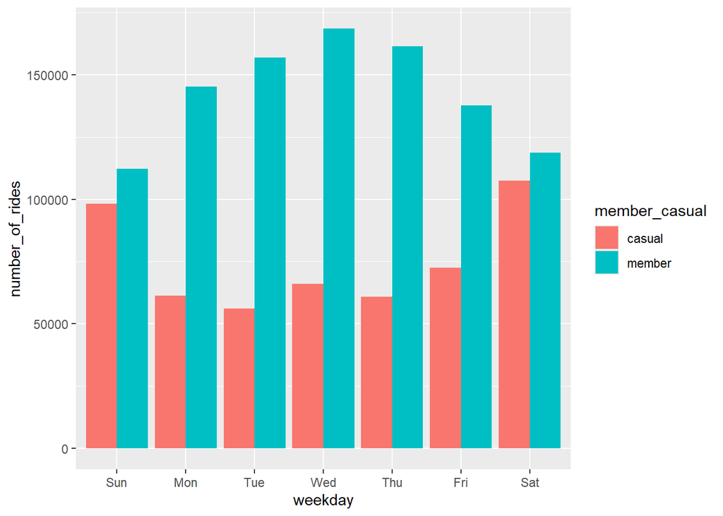

```r
all_trips_v3 %>%
  mutate(weekday = wday(started_at, label = TRUE)) %>%
  group_by(member_casual, weekday) %>%
  summarise(number_of_rides = n()
            ,average_duration = mean(ride_length)) %>%
  arrange(member_casual, weekday) %>%
  ggplot(aes(x = weekday, y = number_of_rides, fill = member_casual)) +
  geom_col(position = "dodge")
```

###Let’s visualize the number of rides by bike type

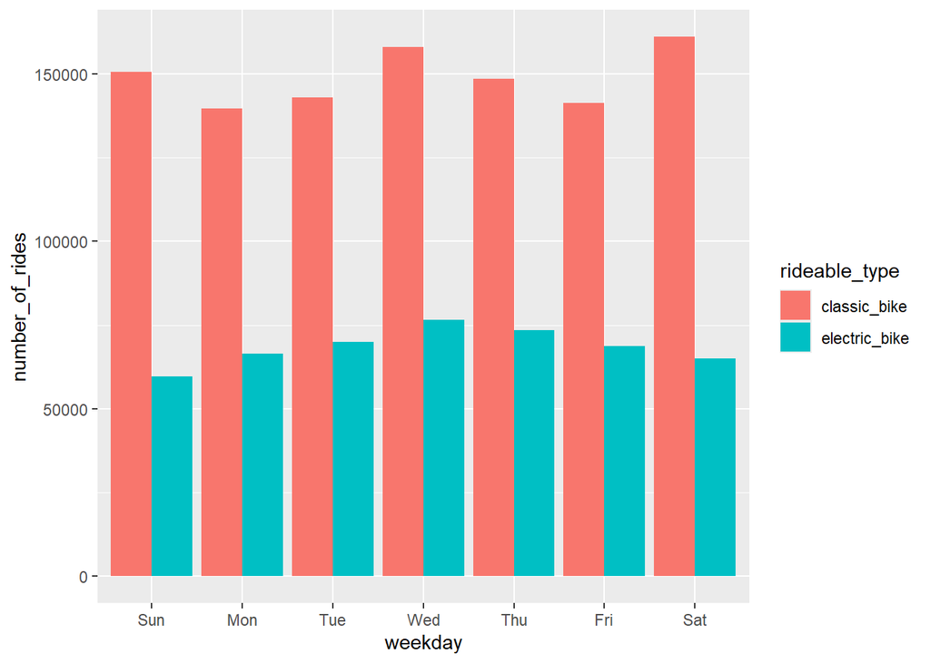

```r
all_trips_v3 %>%
  mutate(weekday = wday(started_at, label = TRUE)) %>%
  group_by(rideable_type, weekday) %>%
  summarise(number_of_rides = n()
            ,average_duration = mean(ride_length)) %>%
  arrange(rideable_type, weekday) %>%
  ggplot(aes(x = weekday, y = number_of_rides, fill = rideable_type)) +
  geom_col(position = "dodge")
```

###Load librery ggvis to visualize data

```r
install.packages("ggvis")
library(ggvis)
library(dplyr)
library(lubridate)
```

###Let’s create a visualization for average duration for member_casual

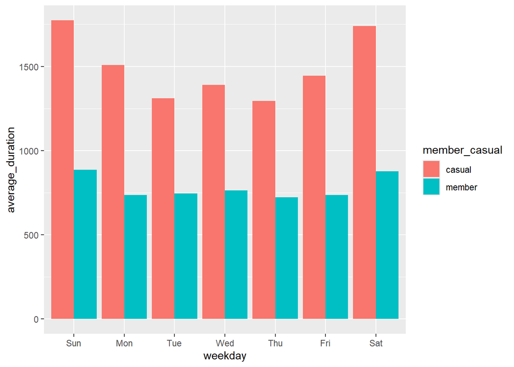

```r
all_trips_v3 %>%
  mutate(weekday = wday(started_at, label = TRUE)) %>%
  group_by(member_casual, weekday) %>%
  summarise(number_of_rides = n()
            ,average_duration = mean(ride_length)) %>%
  arrange(member_casual, weekday) %>%
  ggplot(aes(x = weekday, y = average_duration, fill = member_casual)) +
  geom_col(position = "dodge")
```

###Let’s create a visualization for average duration for rideable_type

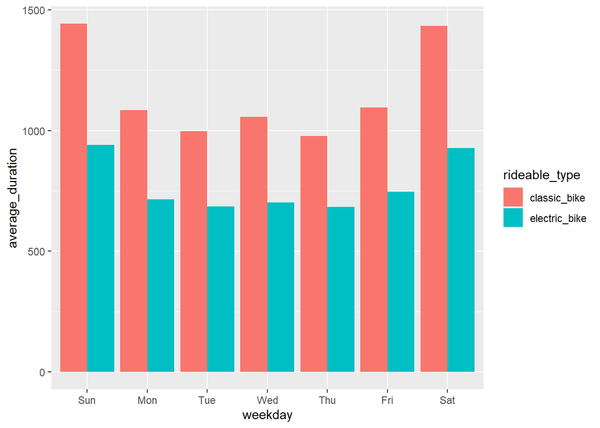

```r
all_trips_v3 %>%
  mutate(weekday = wday(started_at, label = TRUE)) %>%
  group_by(rideable_type, weekday) %>%
  summarise(number_of_rides = n()
            ,average_duration = mean(ride_length)) %>%
  arrange(rideable_type, weekday) %>%
  ggplot(aes(x = weekday, y = average_duration, fill = rideable_type)) +
  geom_col(position = "dodge")
```

=================================================  
#STEP 5: EXPORT SUMMARY FILE FOR FURTHER ANALYSIS  
=================================================  
Create a csv file that we will visualize in Excel, Tableau, or my presentation software  
read more here: https://datatofish.com/export-dataframe-to-csv-in-r/

```r
avg_ride_length_member_casual <- aggregate(all_trips_v3$ride_length ~ all_trips_v3$member_casual +
                        all_trips_v3$day_of_week, FUN = mean)

write.csv(avg_ride_length_member_casual, file = 'F:\\my_Data\\Case_study_1_data\\My_final_analysis\\2024_divvy_bikeshare_analysis\\avg_ride_length_member_casual_Q1Q2.csv')
```

```r
avg_ride_length_rideable_type <- aggregate(all_trips_v3$ride_length ~ all_trips_v3$rideable_type +
                                              all_trips_v3$day_of_week, FUN = mean)
write.csv(avg_ride_length_rideable_type, file = 'F:\\my_Data\\Case_study_1_data\\My_final_analysis\\2024_divvy_bikeshare_analysis\\avg_ride_length_rideable_type.csv')
```

```r
write.csv(all_trips_v3, file = 'F:\\my_Data\\Case_study_1_data\\My_final_analysis\\2024_divvy_bikeshare_analysis\\all_trips_Q1Q2_granularData.csv')

all_ride_data <- read_csv("F:\\my_Data\\Case_study_1_data\\My_final_analysis\\2024_divvy_bikeshare_analysis\\all_trips_Q1Q2_granularData.csv")
```

```
## ──────────────────────────────────────────────────────── Delimiter: "," chr
## (10): ride_id, rideable_type, start_station_name, start_station_id, end... dbl
## (4): ...1, ...2, year, ride_length dttm (2): started_at, ended_at date (1):
## date
```